# pittsburgh_zoning

Yesterday, the [New York Times published an article](https://www.nytimes.com/interactive/2019/06/18/upshot/cities-across-america-question-single-family-zoning.html) about zoning in U.S. cities, particularly single-unit detached residential housing. The article did not include Pittsburgh, so I downloaded the [zone shapefile from the WPRDC](https://data.wprdc.org/dataset/zoning1) and made my own map.

This blog quickly goes through the steps to make the map and other graphs about the data.

First, load the required libraries and set up the environment:

```r
library(tidyverse)
library(sf)
library(ggmap)
library(janitor)
library(hrbrthemes)

options(scipen = 999)
```

Read in the shapefile with `st_read`:

```r
shapefile <- st_read("data/Zoning.shp")
glimpse(shapefile)
```

```
## Observations: 1,055
## Variables: 19
## $ objectid   <dbl> 1003, 1004, 1005, 1006, 1007, 1008, 1009, 1010, 1011,…
## $ area       <dbl> 313156.6, 6630129.1, 2907276.6, 14974381.6, 976915.9,…
## $ perimeter  <dbl> 3950.255, 27722.334, 14342.342, 51430.490, 7215.884, …
## $ zoning_    <dbl> 505, 507, 627, 640, 660, 666, 740, 806, 878, 914, 924…
## $ zoning_id  <dbl> 505, 507, 627, 640, 660, 666, 740, 806, 878, 914, 924…
## $ zon_new    <fct> RP, R2-L, UNC, R2-L, UNC, R1D-M, R1A-VH, R1D-L, R1D-H…
## $ shape_leng <dbl> 3950.255, 27722.334, 14342.342, 51430.490, 8527.517, …
## $ correction <fct> NA, NA, NA, NA, NA, NA, NA, NA, NA, NA, NA, NA, NA, N…
## $ full_zonin <fct> RESIDENTIAL PLANNED UNIT DEVELOPMENT, TWO-UNIT RESIDE…
## $ legendtype <fct> Planned Unit Development, Two-Unit Residential, Urban…
## $ municode   <fct> http://library.municode.com/HTML/13525/level4/PIZOCO_…
## $ status     <fct> Approved, Approved, Approved, Approved, Approved, App…
## $ created_us <fct> pgh.admin, pgh.admin, pgh.admin, pgh.admin, pgh.admin…
## $ created_da <fct> 2019-04-16T15:07:40.150Z, 2019-04-16T15:07:40.150Z, 2…
## $ last_edite <fct> pgh.admin, pgh.admin, pgh.admin, pgh.admin, pgh.admin…
## $ last_edi_1 <fct> 2019-04-16T15:07:40.150Z, 2019-04-16T15:07:40.150Z, 2…
## $ Shape__Are <dbl> 313156.6, 6630129.1, 2907276.6, 14975696.6, 1117801.4…
## $ Shape__Len <dbl> 3950.255, 27722.334, 14342.342, 51227.951, 8549.557, …
## $ geometry   <POLYGON [°]> POLYGON ((-79.98031 40.4449..., POLYGON ((-79…
```

We need to munge the data to get it in shape for analysis. This makes some simple TRUE|FALSE flags for basic zone information and uses `case_when` to create `type`, which represents aggregated zone types.

```r
df <- shapefile %>%
  mutate(residential = str_detect(full_zonin, "RESIDENT"),
         single_unit = str_detect(full_zonin, "SINGLE-UNIT"),
         attached = str_detect(full_zonin, "ATTACHED"),
         type = case_when(residential == TRUE & single_unit == TRUE & attached == FALSE ~ "Single-unit detached residential",
                          residential == TRUE & single_unit == FALSE | attached == TRUE ~ "Other residential",
                          full_zonin == "EDUCATIONAL/MEDICAL INSTITUTION" ~ "Educational/Medical",
                          residential == FALSE ~ "Other non-residential"),
         type = factor(type, levels = c("Single-unit detached residential",
                                        "Other residential",
                                        "Educational/Medical",
                                        "Other non-residential")),
         alpha_flag = type == "Single-unit detached residential")
df %>%
  st_drop_geometry() %>%
  head()
```

```
##   objectid       area perimeter zoning_ zoning_id zon_new shape_leng
## 1     1003   313156.6  3950.255     505       505      RP   3950.255
## 2     1004  6630129.1 27722.334     507       507    R2-L  27722.334
## 3     1005  2907276.6 14342.342     627       627     UNC  14342.342
## 4     1006 14974381.6 51430.490     640       640    R2-L  51430.490
## 5     1007   976915.9  7215.884     660       660     UNC   8527.517
## 6     1008  2696972.2 11090.498     666       666   R1D-M  11090.498
##   correction                                        full_zonin
## 1       <NA>              RESIDENTIAL PLANNED UNIT DEVELOPMENT
## 2       <NA>                  TWO-UNIT RESIDENTIAL LOW DENSITY
## 3       <NA>                     URBAN NEIGHBORHOOD COMMERCIAL
## 4       <NA>                  TWO-UNIT RESIDENTIAL LOW DENSITY
## 5       <NA>                     URBAN NEIGHBORHOOD COMMERCIAL
## 6       <NA> SINGLE-UNIT DETACHED RESIDENTIAL MODERATE DENSITY
##                         legendtype
```

[output cut: 34 more lines]

This counts the number of rows per full zone description (`full_zonin`) and `type`:

```r
df_zones <- df %>%
  count(full_zonin, type, sort = TRUE) %>%
  st_drop_geometry()
df_zones
```

```
## # A tibble: 59 x 3
##    full_zonin                              type                           n
##  * <fct>                                   <fct>                      <int>
##  1 PARKS AND OPEN SPACE                    Other non-residential        148
##  2 LOCAL NEIGHBORHOOD COMMERCIAL           Other non-residential        126
##  3 SINGLE-UNIT DETACHED RESIDENTIAL LOW D… Single-unit detached resi…    75
##  4 MULTI-UNIT RESIDENTIAL MODERATE DENSITY Other residential             69
##  5 HILLSIDE                                Other non-residential         65
##  6 URBAN INDUSTRIAL                        Other non-residential         52
##  7 TWO-UNIT RESIDENTIAL LOW DENSITY        Other residential             51
##  8 SINGLE-UNIT DETACHED RESIDENTIAL HIGH … Single-unit detached resi…    44
##  9 SINGLE-UNIT ATTACHED RESIDENTIAL HIGH … Other residential             43
## 10 RESIDENTIAL PLANNED UNIT DEVELOPMENT    Other residential             42
## # … with 49 more rows
```

Create a basic bar chart to show the distribution of `type`:

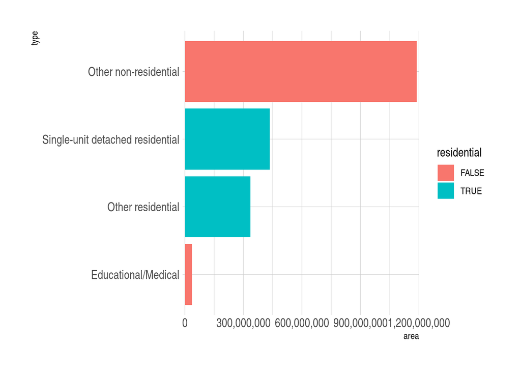

```r
df %>%
  st_drop_geometry() %>%
  group_by(type, residential) %>%
  summarize(area = sum(area)) %>%
  ungroup() %>%
  mutate(type = fct_reorder(type, area)) %>%
  ggplot(aes(type, area, fill = residential)) +
  geom_col() +
  scale_y_comma() +
  coord_flip() +
  theme_ipsum()
```

Use a bar chart to show the distribution of `full_zonin`:

[figure not shown]

```r
df %>%
  st_drop_geometry() %>%
  group_by(full_zonin, residential) %>%
  summarize(area = sum(area)) %>%
  ungroup() %>%
  mutate(full_zonin = fct_reorder(full_zonin, area)) %>%
  ggplot(aes(full_zonin, area, fill = residential)) +
  geom_col() +
  scale_y_comma() +
  coord_flip() +
  theme_ipsum()
```

This calculates the total land area zoned for any type of residential housing:

```r
df %>%
  st_drop_geometry() %>%
  mutate(single_unit_flag = type == "Single-unit detached residential") %>%
  filter(residential == TRUE) %>%
  summarize(total_area = sum(area))
```

```
##   total_area
## 1  770835393
```

This calculates the % of residential zoning that is zoned for single-unit detached residential housing units:

```r
df %>%
  st_drop_geometry() %>%
  filter(residential == TRUE) %>%
  mutate(single_unit_flag = (type == "Single-unit detached residential")) %>%
  group_by(single_unit_flag) %>%
  summarize(zone_area = sum(area)) %>%
  mutate(pct_area = zone_area / sum(zone_area))
```

```
## # A tibble: 2 x 3
##   single_unit_flag  zone_area pct_area
##   <lgl>                 <dbl>    <dbl>
## 1 FALSE            335471796.    0.435
## 2 TRUE             435363597.    0.565
```

This creates a map of the zones, fills them by `type`, and overlays it on a GoogleMaps basemap:

[figure not shown]

```r
#register_google(key = "your key here")
pgh_map <- get_map(location = "Pittsburgh, PA", zoom = 12, maptype = "roadmap", source = "google")

ggmap(pgh_map) +
  geom_sf(data = df %>% filter(type != "Other non-residential"), aes(fill = type), inherit.aes = FALSE, size = .5, alpha = 1, color = NA) +
  coord_sf(crs = st_crs(4326)) +
  scale_fill_manual("Zone type",
                      values = c("#ea60b9", "#4cafc5", "yellow", "light grey")) +
  labs(title = "56% of residential zoned land area is single-family detached residential",
         subtitle = "City of Pittsburgh zoning",
         caption = "@conor_tompkins, data from WPRDC") +
  theme_void()
```

I use `scale_fill_manual` to manually set the color palette to match the NYTimes article.